# Eighth Week: Text Analysis in R

To be, or not to be

Parand Alizadeh

2018-05-05 02:22:38

> با استفاده از بسته gutenberg داده های لازم را به دست آورید و به سوالات زیر پاسخ دهید.

۱. چارلز دیکنز نویسنده معروف انگلیسی بالغ بر چهارده رمان (چهارده و نیم) نوشته است. متن تمامی کتاب های او را دانلود کنید و سپس بیست لغت برتر استفاده شده را به صورت یک نمودار ستونی نمایش دهید. (طبیعتا باید ابتدا متن را پاکسازی کرده و stopping words را حذف نمایید تا به کلماتی که بار معنایی مشخصی منتقل می کنند برسید.)

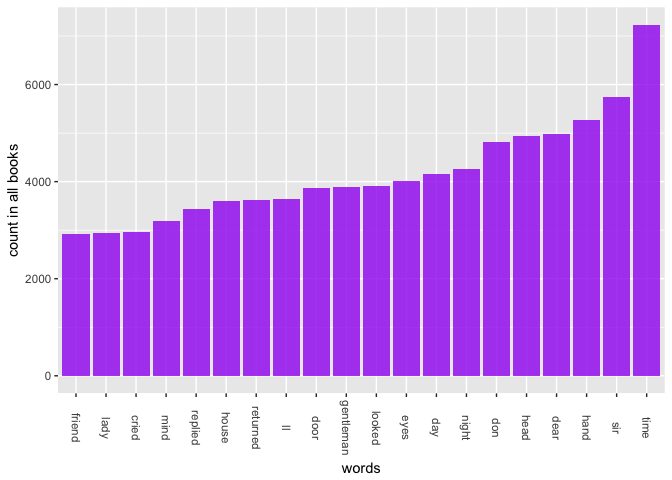

۲. ابر لغات ۲۰۰ کلمه پرتکرار در رمان های چارلز دیکنز را رسم نمایید. این کار را با بسته wordcloud2 انجام دهید. برای دانلود می توانید به لینک زیر مراجعه کنید.

https://github.com/Lchiffon/wordcloud2

به علت خوب کشیده نشدن عکس در کامپیوتر من، کد ضمیمه شده است.

```r
library(gutenbergr)
library(dplyr)
library(tm)
library(wordcloud)
library(stringr)
library(tidytext)
library(ggplot2)
library(wordcloud2)

ids = c(580, 730, 967, 700, 917, 968, 821, 766, 1023, 786, 963, 98, 1400, 883, 564)



#dickens = list()
#dickensbooks = list()

#for (i in 1:length(ids)){

#  x = ids[i]
#  b  = gutenberg_download(x)
#  dickensbooks[[i]] = b
#}

for (i in 1:length(ids)){

  book  = dickensbooks[[i]]
  book = book %>%
    str_replace_all("\"","") %>%
    str_replace_all("[[:punct:]]","") %>%
    str_split(pattern = "\\s") %>%
    unlist() %>%
    table() %>%
    as.data.frame(stringsAsFactors = F)

  colnames(book) = c("word","count")

  book = book  %>%
    filter(!str_to_lower(word) %in% stop_words$word) %>%
    filter(nchar(word)>1) %>%
    filter(!str_detect(word, "\\d")) %>%
    mutate(proper = !word %in% str_to_lower(word)) %>%
    mutate(book_no = x)

  dickens[[i]] = book
}

alls = bind_rows(dickens)

alls %>% filter(proper != TRUE) -> oth

oth %>% group_by(word) %>% summarise(totalCount = sum(count)) -> merged
merged = arrange(merged, -totalCount)


best = head(merged, 200)


wordcloud2(best, figPath = "~/Desktop/Data Analysis/hw_08/hw_08/images/dickens1_1.png" )
```

[interactive chart not shown]

۳. اسم پنج شخصیت اصلی در هر رمان دیکنز را استخراج کنید و با نموداری تعداد دفعات تکرار شده بر حسب رمان را رسم نمایید. (مانند مثال کلاس در رسم اسامی شخصیت ها در سری هر پاتر)

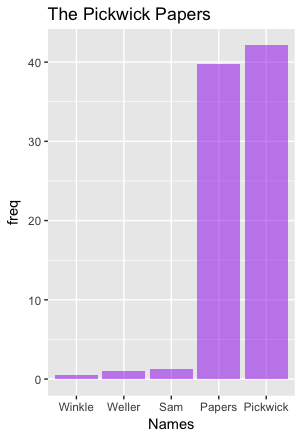

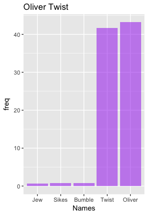

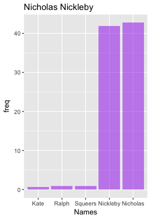

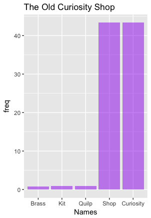

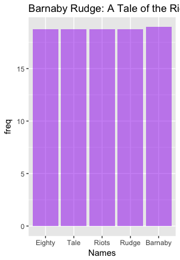

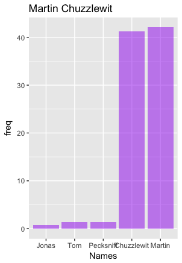

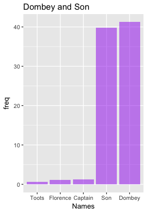

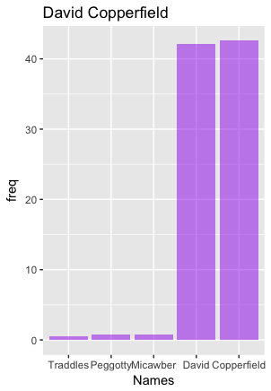

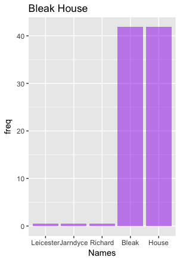

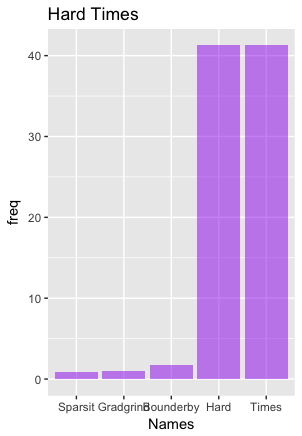

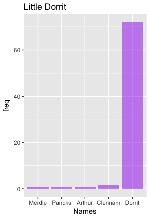

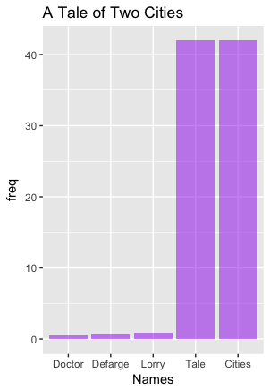

[3 more figures not shown]

۴. در بسته tidytext داده ایی به نام sentiments وجود دارد که فضای احساسی لغات را مشخص می نماید. با استفاده از این داده نمودار ۲۰ لغت برتر negative و ۲۰ لغت برتر positive را در کنار هم رسم نمایید. با استفاده از این نمودار فضای حاکم بر داستان چگونه ارزیابی می کنید؟ (به طور مثال برای کتاب داستان دو شهر فضای احساسی داستان به ترتیب تکرر در نمودار زیر قابل مشاهده است.)

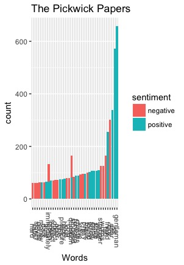

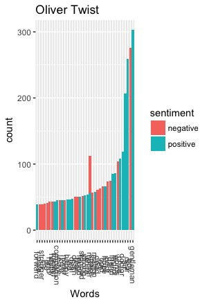

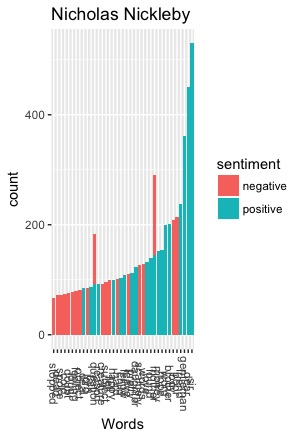

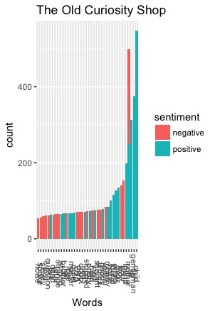

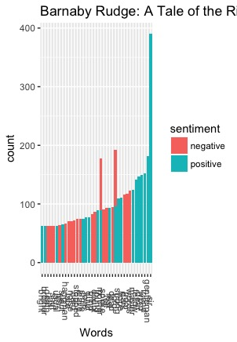

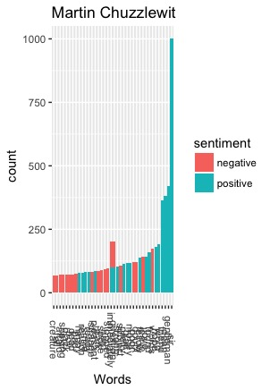

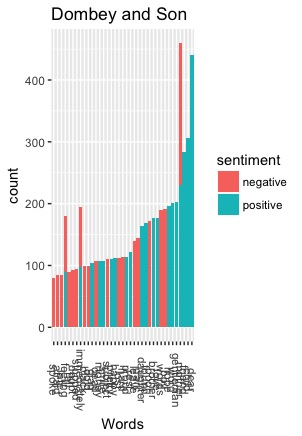

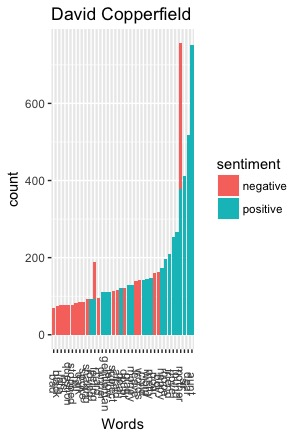

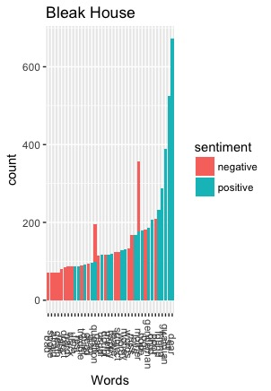

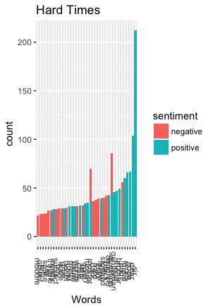

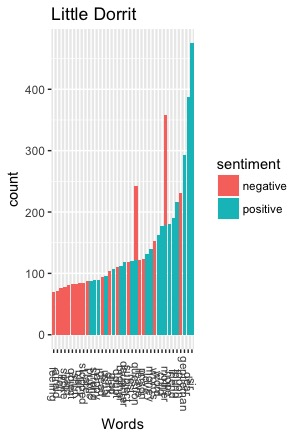

[4 more figures not shown]

۵. متن داستان بینوایان را به ۲۰۰ قسمت مساوی تقسیم کنید. برای هر قسمت تعداد لغات positive و negative را حساب کنید و سپس این دو سری زمانی را در کنار هم برای مشاهده فضای احساسی داستان رسم نمایید.

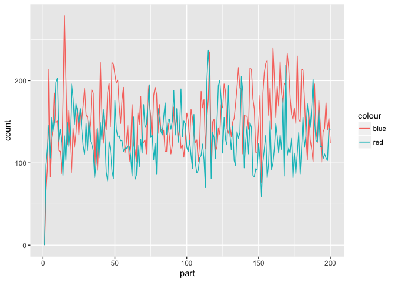

۶. ابتدا ترکیبات دوتایی کلماتی که پشت سر هم می آیند را استخراج کنید و سپس نمودار ۳۰ جفت لغت پرتکرار را رسم نمایید.

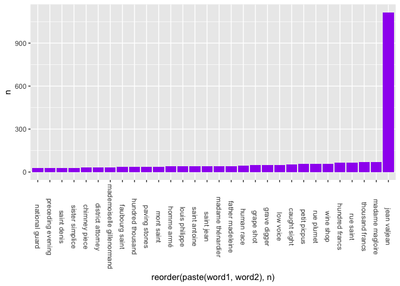

۷. جفت کلماتی که با she و یا he آغاز می شوند را استخراج کنید. بیست فعل پرتکراری که زنان و مردان در داستان های دیکنز انجام می دهند را استخراج کنید و نمودار آن را رسم نمایید.

به علت کم بودن سرعت اجرا در کتابهای دیکنز، از بینوایان استفاده شد.

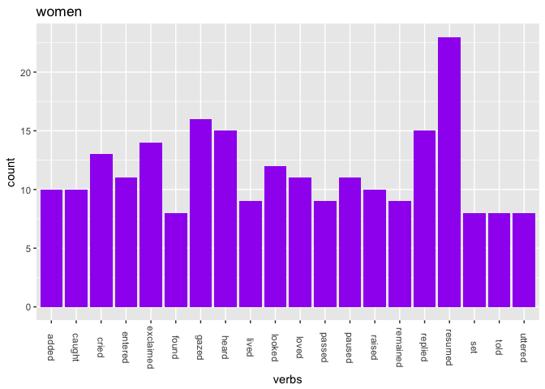

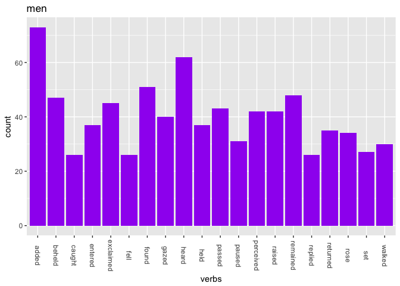

۸. برای کتاب های دیکنز ابتدا هر فصل را جدا کنید. سپی برای هر فصل 1-gram, 2-gram را استخراج کنید. آیا توزیع N-gram در کارهای دیکنز یکسان است؟ با رسم نمودار هم این موضوع را بررسی کنید.